# How granplot works

`granplot`

Usage: recommends statistical distribution plots of bivariate time granularities that aids systematic exploration

granplot(.data, gran1 = NULL, gran2 = NULL, response = NULL, plot_type = NULL, facet_h = 31, …)

- gran1: the first granularity acting as the facet variable
- gran2: the granularity which is to be plotted across x-axis
- response: the univariate time series to be plotted
- plot_type: the type of distribution plot preferred
- facet_h: the highest number of levels for facet variables above which facetting is not recommended

granplot is useful for exploring statistical distributions for bivariate granularities. It provides the plot recommendations given two granularities. Recommendations for plotting will vary depending on which granularity is placed on the x-axis and which one across facets.

granplot uses `gran_advice` to obtain the recommendations of distribution plots depending on the levels(very high/high/medium/low) of the two granularities plotted. Assumptions are made to ensure display is not too cluttered by the space occupied by various kinds of distribution plots.

- very high (facet) and any levels of x-axis

  plots_list <- c(“decile”, “percentile”)
- high (facet) and very high(x-axis)

  plots_list <- c(“decile”, “percentile”)
- high (facet) and high(x-axis)

  plots_list <- c(“decile”, “percentile”)
- high(facet) and medium(x-axis)

  plots_list <- c(“decile”, “percentile”)
- high(facet), low(x-axis)

  plots_list <- c(“ridge”, “violin”, “lv”, “density”)
- medium(facet), very high (x-axis)

  plots_list <- c(“decile”, “percentile”)
- medium(facet), high (x-axis)

  plots_list <- c(“decile”, “percentile”) }
- medium(facet), medium (x-axis)

  plots_list <- c(“decile”, “percentile”)
- medium(facet), low (x-axis)

```
plots_list <- c("ridge", "violin", "lv", "density")
```

- low(facet), very high (x-axis)

  plots_list <- c(“boxplot”, “lv”, “percentile”, “decile”)
- low(facet), medium (x-axis)

  plots_list <- c(“ridge”, “violin”, “lv”, “density”, “percentile”, “decile”)
- low(facet), low (x-axis)

  plots_list <- c(“ridge”, “violin”, “lv”, “boxplot”, density“,”percentile“,”decile")

# Default values

Default levels are chosen as very high/high/medium/low based on levels of common temporal granularities like day of the month, day of a fortnight or day of a week. Users are free to change these values.

levels_high = 31  
levels_medium = 14  
levels_low = 7

Minimum number of observations for combinations of time granularities  
Assumptions are made to ensure decile/percentile/density based plots are avoided for too few observations

However, warnings are generated in the following order:

- If two granularities fed are clashes, then no other warnings will be generated other than that they are clashes.
- If two granularities fed are harmonies, but levels of facets too high for facetting, warnings will be generated.
- If two granularities fed are harmonies and levels of facets not beyond the default or user assigned highest value of facets allowed, then warnings will be generated in case number of observations for any combination(s) too few to draw a distribution plot or if there is any inter or intra facet heterogeneity.

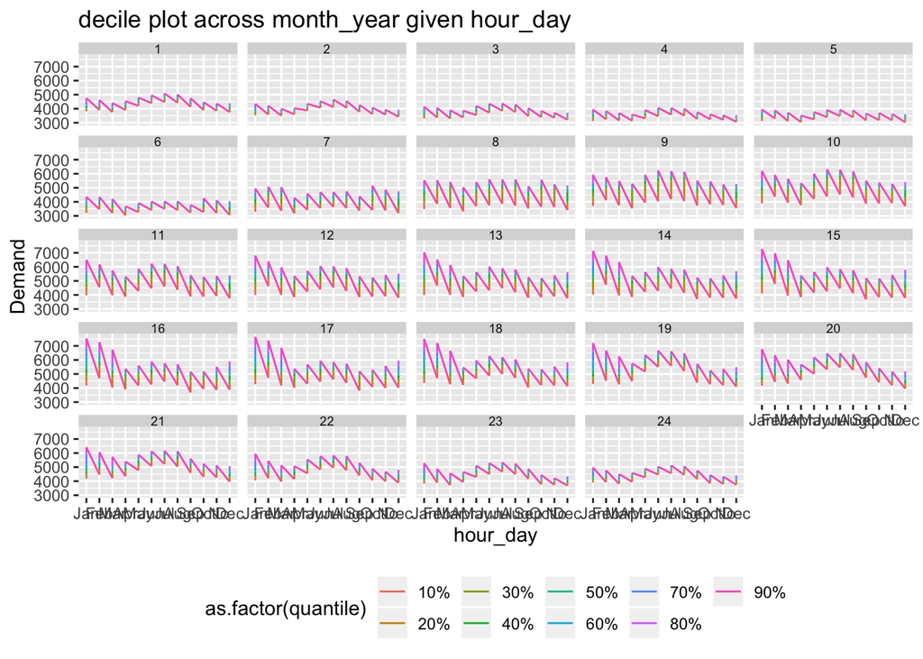

User is free to choose any one of the seven distribution plots (“ridge”, “violin”, “lv”, “boxplot”, density“,”percentile“,”decile") in plot_type.If plot_type is not specified, the first one from the recommended list is picked up. To see the list of recommended distribution plots, use the function `gran_advice`.

```r
gravitas:::gran_advice(data2, gran1="hour_day", gran2 = "month_year")
```

```
## [1] "decile"     "percentile"
```